# LT5 Notebook: Factorial ANOVA

# Post script for further learning: 2 x 2 mixed factoral ANOVA with interaction as a linear model

## The data

To demonstrate mixed 2 x 2 ANOVA with an interaction, we are going to use the data from Experiment 3 of; Zhang, T., Kim, T., Brooks, A. W., Gino, F., & Norton, M. I. (2014). A “present” for the future: The unexpected value of rediscovery. Psychological Science, 25, 1851-1860.

The premise of this study was that people often keep diaries to help them remember and contemplate the events of their lives. Months or years later, when people look back through their diary entries, they often gain insights about the overall meaningfulness of these events, as well as their emotional reactions to them.

With this in mind, Zhang et al. (2014) sought to examine whether individuals are more likely to mispredict the value of rediscovering ordinary events than to mispredict the value of rediscovering extraordinary events, which are more memorable. Becuase of this, it was predicted that ordinary events will come to be perceived as more extraordinary over time, whereas perceptions of extraordinary events will not change across time.

To test this hypothesis, the authors recruited individuals who were currently involved in romantic relationships, and asked half of the participants to write about an extraordinary day with their romantic partner (Valentine’s Day), and the other half to write about an ordinary day with their romantic partner (what happened two days ago). The authors then asked participants rate the degree of extraordinariness on a scale of 1 to 7 (1 = extremely ordinary, 4 = neither ordinary nor extraordinary, 7 = extraordinary) for their diary entry.

Three months later, the authors contacted all of the participants, and had them read their description of the extraordinary or ordinary day, and then rate how extraordinary the event was in retrospect using the same scale. This is a classic mixed 2 x 2 ANOVA with an interaction. The outcome in this case is ratings of extraordinariness and the predictors are time with two levels (i.e., time 1 and time 2) and condition with two levels (i.e., ordinary or extraordinary day). The design is mixed because time is a within-person factor and condition is a between person factor.

Becasue of the mixed nature of this design, the data is structured slightly differently to how we have been working with to date. Instead of being in horizontal format with each participants score for each variable listed in each row, the data for a mixed design needs to be in vertical format with each participant’s score for each time point listed in each row. Lets load the dataset into R and we’ll look at what this means.

```r
extraordinary <- read_csv("C:/Users/tc560/Dropbox/Work/LSE/PB130/LT5/Workshop/extraordinary.csv")
View(extraordinary)
```

If you go to the data file and click on the “ID” column, it will sort the data file from low to high. As you will see, when you sort the data by ID, each individual has 2 data rows. The first is for the rating of extraordinariness at time point 1 (coded 0) and the second is for the rating of extraordinariness at time point 2 (Coded 1). This is the within-person factor. The condition that the person belongs to (i.e., ordinary coded 0 or extraordinary coded 1) is the same across each time point becuase this is the between-person factor - the factor that differs between persons, but not within them. Structured this way, the linear model can estiamte the effect of time (i.e., differences between the time points) and condition (i.e., the differences between the conditions) simultaneously.

As always, before we delve into this topic lets just clarify the research question and null hypothesis we are testing:

*Research Question* - Is the effect of time on ratings of event extrordinariness moderated by experimental condition?

*Null Hypothesis* - The interaction of time and condition on event extraordinariness will be zero.

## Setting up the linear model

```r
linear.model4 <- lm(extraordinary ~ 1 + time + Condition + time*Condition, data=extraordinary)
summary(linear.model4)
```

```
##
## Call:
## lm(formula = extraordinary ~ 1 + time + Condition + time * Condition,
##     data = extraordinary)
##
## Residuals:
##     Min      1Q  Median      3Q     Max
## -3.5152 -0.7344  0.0625  1.0625  3.2656
##
## Coefficients:
##                Estimate Std. Error t value Pr(>|t|)
## (Intercept)      2.7344     0.1623  16.845  < 2e-16 ***
## time             1.2031     0.2296   5.241 3.34e-07 ***
## Condition        1.6141     0.2278   7.085 1.34e-11 ***
## time:Condition  -1.0365     0.3222  -3.217  0.00146 **
## ---
## Signif. codes:  0 '***' 0.001 '**' 0.01 '*' 0.05 '.' 0.1 ' ' 1
##
## Residual standard error: 1.299 on 256 degrees of freedom
## Multiple R-squared:  0.2249, Adjusted R-squared:  0.2158
## F-statistic: 24.76 on 3 and 256 DF,  p-value: 4.216e-14
```

We already know that in a linear model with an interaction term, the estimates for b1 and b2 become conditional effects - differences between the level of the predictor when the other predictor is 0. So here the intercept estimate is the mean extraordinary rating for the people in the ordinary condition (coded 0) at time 1 (coded 0). The slope for time is the boost needed to the intercept to find the mean extraordinary rating for people in the ordinary condition (coded 0) at time point 2 (coded 1). The slope for condition is the boost needed to the intercept to find the mean extraordinary rating for people in the extraordinary condition (coded 1) at time point 1 (coded 0).

As we know from LT3, these main effects, as we have been calling them, are irrelevant in the presence of a significant interaction term because they will depend on the level of the moderator. In this case, the interaction of time and condition means that the effect of time on extraordinariness depends on the condition that participants were assigned to. I don’t want you to focus on the t ratios and p values here becuase this is a mixed design and therefore the errors in the linear model are wrong (more below). For now, lets just move forward to probing this interaction.

## Probing the interaction

Okay, so just like moderation analysis, the slope for the interaction term doesn’t really tell us a great deal beyond the fact that the effect of the predictor on the outcome depends on the level of the moderator. In order to better understand our interaction, we need to probe it. By now, we should know how to do this with categorical variables. We’re just going to examine the conditional effects of time on ratings of extrodinariness across the two levels of our moderator. As we saw in LT3, we can easily do this with the pickpoint() function.

```r
pickapoint(linear.model4, dv='extraordinary', iv='time', mod='Condition')
```

```
## Call:
## pickapoint(model = linear.model4, dv = "extraordinary", iv = "time",
##     mod = "Condition")
## Conditional effects of  time  on  extraordinary  at values of  Condition
##  Condition    Effect       SE         t            p       llci      ulci
##          0 1.2031250 0.229561 5.2409818 3.350795e-07  0.7510481 1.6552019
##          1 0.1666667 0.226056 0.7372803 4.616298e-01 -0.2785079 0.6118412
##
## Values for quantitative moderators are the mean and plus/minus one SD from the mean
## Values for dichotomous moderators are the two values of the moderator
```

Now we are getting somewhere! Consisitent with the interaction term, we can see that the effect of time on ratings of extraordinariness depend on what condition the participants belong to. In the ordinary condition, we can see that the mean diffence between time 1 and time 2 ratings of extraordiness increased by 1.2 points. However, for people randomly assigned to the extraordinalry condition, the difference between time 1 and time 2 ratings of extraordinariness is much smaller - only 0.17.

## Plotting the interaction

To get a better understading of this moderation, we can plot it. For this, I’m going to create a new data object called data thast will contain the means and standard errors for each condition, at each time point so that I can then plot them on an interaction plot. As such, I will use ggplot() this time rather than interation.plot() as we did in LT3 becuase I with the standard errors, can plot the confidence intervals around the means for each condition at each time point. Lets go ahead and create that plot.

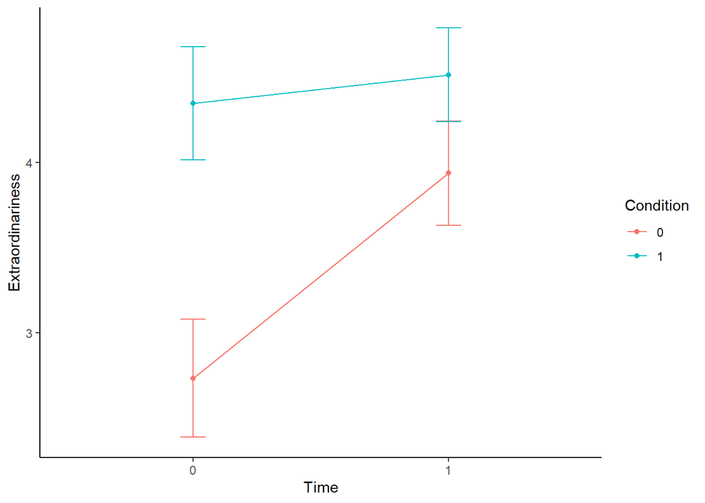

```r
data <- extraordinary %>%
  group_by(time, Condition) %>%
  summarise(extra_mean = mean(extraordinary), extra_se = psych::describe(extraordinary)$se) ## this first chunk creates a new dataset called "data" which summarises the means and standard errors for each condition at each time point. Find the "data" object in your R environment and check it out!

data %>%
 ggplot(aes(x=as.factor(time), y=extra_mean, colour=as.factor(Condition))) + # I am now plotting time against the extraordinary rating means for each time point across each condition. I am forcing the time and condition variables to factors so that R does not interpret them as continuous variables
  geom_line(aes(group=as.factor(Condition))) +
     geom_point() +
     geom_errorbar(aes(ymin=extra_mean-1.96*extra_se, ymax=extra_mean+1.96*extra_se), width=.1) + # I am adding the   error bars that depict the upper and lower confidence from +/- 1.96 SE of the means
  labs(x = "Time",
       color  = "Condition",
       y = "Extraordinariness") +
theme_classic()
```

We can see clearly here what is happening in the data. Ordinary experiences were perceived as far more extraordinary at Time 2 than at Time 1, whereas these ratings for the extraordinary experiences did not differ between Time 1 and Time 2. This is precicely the hypothesis that Zhang et al had. Ordinary events come to be perceived as more extraordinary over time, whereas perceptions of extraordinary events do not change across time.

## Equivalence with aov()

Again, I want to show you equivalence of the lm() with aov() for this mixed 2 x 2 ANOVA to further demonstrate how ANOVA is just a special case of regression. Special in that the predictor variables are categorical and not continuous.

I said above that lm() and aov() are both appropriate methods for anaysing the 2 x 2 ANOVA. However, when there is a mixed deisgn, like this one, aov() should ALWAYS be used. Why? Think back to the coefficients for the linear model and remember I said that we cannot interpret the t values and p values becuase the error portion of the model is wrong? Well thats becuase when we stacked the data into long format we doubled the sample size (i.e., each person has 2 rows, one for time 1 and one for time 2) and the lm() function has no way of knowing that those additional observations are actually grouped by ID. It therefore assumes the sample size is 260 rather than 130 and, as such, overestimates the degrees of freedom in the residual. Thats why we cannot rely on the lm() for null hypothesis significance testing.

But this said, the analyses are equivalent and the focal coefficient - the estimate for the interaction - will be identical. For ease, I’m going to run the supernova for the linear model and the summary for the ANOVA model to demonstrate this.

```r
supernova(linear.model4)
```

```
##  Analysis of Variance Table (Type III SS)
##  Model: extraordinary ~ 1 + time + Condition + time * Condition
##
##                                        SS  df     MS      F    PRE     p
##  -------------- ----------------- ------- --- ------ ------ ------ -----
##           Model (error reduced) | 125.281   3 41.760 24.764 0.2249 .0000
##            time                 |  46.320   1 46.320 27.468 0.0969 .0000
##       Condition                 |  84.654   1 84.654 50.200 0.1639 .0000
##  time:Condition                 |  17.452   1 17.452 10.349 0.0389 .0015
##           Error (from model)    | 431.704 256  1.686
##  -------------- ----------------- ------- --- ------ ------ ------ -----
##           Total (empty model)   | 556.985 259  2.151
```

```r
anova.model4 <- aov(extraordinary ~ as.factor(time)*as.factor(Condition) + Error(as.factor(ID)/as.factor(time)), data = extraordinary)
summary(anova.model4) ## the Error addition to the ANOVA model tells R that this is a mixed design and that time is the within-person factor with each person categorised by their ID
```

```
##
## Error: as.factor(ID)
##                       Df Sum Sq Mean Sq F value  Pr(>F)
## as.factor(Condition)   1  78.04   78.04   35.31 2.5e-08 ***
## Residuals            128 282.94    2.21
## ---
## Signif. codes:  0 '***' 0.001 '**' 0.01 '*' 0.05 '.' 0.1 ' ' 1
##
## Error: as.factor(ID):as.factor(time)
##                                       Df Sum Sq Mean Sq F value   Pr(>F)
## as.factor(time)                        1  29.78  29.785   25.63 1.41e-06 ***
## as.factor(time):as.factor(Condition)   1  17.45  17.452   15.02 0.000169 ***
## Residuals                            128 148.76   1.162
## ---
## Signif. codes:  0 '***' 0.001 '**' 0.01 '*' 0.05 '.' 0.1 ' ' 1
```

Of noting here is the degrees of freedom in the total model and - by extention - the error. In the linear model it is overestimated (i.e., 259) but in the ANOVA model it is correct (i.e., 128) because we have conditioned the between person effects on the within person condition. A mixed factoral ANOVA first outputs the main effect of condition. This is the overall effect of condition on extraordinariness ratings irrespective of time. Those in the extraordinary condition rated the events as more extraodinary overall, irrespective of time point. It then outputs the main effect of time, irrespecitve of condition. Here, experiences seemed more extraordinary overall at Time 2 than they did 3 months earlier, at Time 1, irrespecitve of what condition the participants were in. Sound familiar? Thats right, these are the same as unique effects in regression.

Importantly, however, the ANOVA also outputs the interaction between time and condition, F(1, 128) = 15.02, p < .001. And this, of course, is the focal effect of interest. We can interpret the F ratio and P value for this effect becuase the degrees of freedom in the error portion of the model are correct. And, as we can see, the interaction is significant. What I would like you note here is the symatery between the lm() and aov(). The sum of squares for the interaction term is exactly the same in the linear model and the ANOVA model (17.45). The F ratio and p value is wrong becuase there is no adjustment to the error in the lm(), but the mechanics under the hood are exactly the same.

## Post-hoc testing

As a result of the significant interation term, we should conduct our multiple comparisons by conditioning the effect of time on the experimental condition. We do this in the emmeans() function using the vertical bar |. The vertical bar reads as meaning conditional. Here we will condition the effect of time on experimental condition using |. Lets go ahead and do that now.

```r
extraordinary$time <- factor(extraordinary$time, levels = c("1", "0"))
emmeans(anova.model4, pairwise ~time)
```

```
## Note: re-fitting model with sum-to-zero contrasts
```

```
## NOTE: Results may be misleading due to involvement in interactions
```

```
## $emmeans
##  time emmean    SE  df lower.CL upper.CL
##  1      4.23 0.114 233     4.01     4.46
##  0      3.55 0.114 233     3.33     3.77
##
## Results are averaged over the levels of: Condition
## Warning: EMMs are biased unless design is perfectly balanced
## Confidence level used: 0.95
##
## $contrasts
##  contrast estimate    SE  df t.ratio p.value
##  1 - 0       0.685 0.134 128 5.121   <.0001
##
## Results are averaged over the levels of: Condition
```

```r
emmeans(anova.model4, pairwise ~Condition)
```

```
## Note: re-fitting model with sum-to-zero contrasts
## NOTE: Results may be misleading due to involvement in interactions
```

```
## $emmeans
##  Condition emmean   SE  df lower.CL upper.CL
##          0   3.34 0.13 128     3.09      3.6
##          1   4.44 0.13 128     4.18      4.7
##
## Results are averaged over the levels of: time
## Warning: EMMs are biased unless design is perfectly balanced
## Confidence level used: 0.95
##
## $contrasts
##  contrast estimate    SE  df t.ratio p.value
##  0 - 1        -1.1 0.184 128 -5.942  <.0001
##
## Results are averaged over the levels of: time
```

```r
emmeans(anova.model4, pairwise ~time|Condition)
```

```
## Note: re-fitting model with sum-to-zero contrasts
```

```
## $emmeans
## Condition = 0:
##  time emmean    SE  df lower.CL upper.CL
##  1      3.95 0.162 234     3.63     4.26
##  0      2.74 0.162 234     2.42     3.06
##
## Condition = 1:
##  time emmean    SE  df lower.CL upper.CL
##  1      4.52 0.161 233     4.21     4.84
##  0      4.36 0.161 233     4.04     4.67
##
## Warning: EMMs are biased unless design is perfectly balanced
## Confidence level used: 0.95
##
## $contrasts
## Condition = 0:
##  contrast estimate    SE  df t.ratio p.value
##  1 - 0       1.203 0.191 128 6.313   <.0001
##
## Condition = 1:
##  contrast estimate    SE  df t.ratio p.value
##  1 - 0       0.167 0.188 128 0.888   0.3762
```

The way these contrasts are calcualated is pre-post and therefore the estimates should be reversed to reflect the direction of effects (i.e., negative vlaues indicate increases and vice versa). I have done this in the first line of code above. Of noting is that the point estimate for the contrasts reveal the story: the increase in ratings of extraordinariness are larger for the oridinary group (mean=1.20, SE=0.19, t=6.31) than for the extraordinary group (mean=.17, SE=0.19, t=.89).

## How its written

We submitted the extrodinariness scores at each time point across each group to a 2 (time: pre vs. post) x 2 (group: ordinary vs extraordinary) mixed factorial ANOVA.